# Project: Investigate a Dataset (FBI Gun Data)

- Introduction
- Data Wrangling
- Exploratory Data Analysis
- Conclusions

## Introduction

**The National Instant Criminal Background Check System (NICS)** is a United States system for determining if prospective firearms or explosives buyers' name and birth year match those of a person who is not eligible to buy.

After a prospective buyer completes the appropriate form, the holder of a Federal Firearms License (FFL) initiates the background check by phone or computer. Most checks are determined within minutes, but the FBI has up to three business days to make a determination. After that, the transfer may legally proceed anyway.

The data comes from the FBI's National Instant Criminal Background Check System. The NICS is used by to determine whether a prospective buyer is eligible to buy firearms or explosives. Gun shops call into this system to ensure that each customer does not have a criminal record or isn’t otherwise ineligible to make a purchase. The data has been supplemented with state level data from census.gov.

```python
# import statements for all of the packages i plan to use.
import pandas as pd
import numpy as np
import matplotlib.pyplot as plt
import seaborn as sns

# to make sure all visualizations are plotted inline with the notebook
%matplotlib inline
```

## Data Wrangling

### General Properties

Looking at the two datasets:

**- Columns:** df_gun: **27** df_census: **52**

**- Entries:** df_gun **12485** df_census **85**

**- Data Type:** df_gun **float(23), int(2), str(2)** df_census **str(52)**

**- Null:** So many null cells in both datasets

**- Values in columns:** there are a lot of consistencies that need to be cleaned, specially in the census data

**- Duplicates:** df_gun **none** df_census **4**

### What to clean...

The data is very messy, to get clean dataframes, all extra columns and rows need to be dropped, inconsistent values need to be made the same, datatype should be changed. the two dataframes showld have the same rows/columns format...

#### Cleaning data in df_gun

1. Divide the month column to two columns: month and year, so we can run yearly and monthly analysis
2. Dropping unnecessary columns/rows from my dataset
3. Changing data type to int to make the type consistent

#### Cleaning data in df_us_census

I would like to compare values in both datasets based on time and state. This dataset has states as column heads instead of rows like the df_gun. This will not help me make comparison, so i need to fix it.

> **Note**: I will not need to drop duplicate, since the duplicated rows are all NaN rows that will be dropped later anyway.
1. Dropping unnecessary columns/rows from my dataset
2. Flipping my dataset to switch between columns and rows
3. Changing columns names
4. fixing data inconsistencies
5. Fixing data type

```python
# Loading my two datasets

df_gun = pd.read_excel('gun_data.xlsx')
df_us_census = pd.read_csv('us_census_data1.csv')
```

```python
df_us_census[df_us_census.duplicated(keep=False)]
```

|  | Fact | Fact Note | Alabama | Alaska | Arizona | Arkansas | California | Colorado | Connecticut | Delaware | ... | South Dakota | Tennessee | Texas | Utah | Vermont | Virginia | Washington | West Virginia | Wisconsin | Wyoming |
| --- | --- | --- | --- | --- | --- | --- | --- | --- | --- | --- | --- | --- | --- | --- | --- | --- | --- | --- | --- | --- | --- |
| 65 | NaN | NaN | NaN | NaN | NaN | NaN | NaN | NaN | NaN | NaN | ... | NaN | NaN | NaN | NaN | NaN | NaN | NaN | NaN | NaN | NaN |
| 67 | NaN | NaN | NaN | NaN | NaN | NaN | NaN | NaN | NaN | NaN | ... | NaN | NaN | NaN | NaN | NaN | NaN | NaN | NaN | NaN | NaN |
| 70 | NaN | NaN | NaN | NaN | NaN | NaN | NaN | NaN | NaN | NaN | ... | NaN | NaN | NaN | NaN | NaN | NaN | NaN | NaN | NaN | NaN |
| 75 | NaN | NaN | NaN | NaN | NaN | NaN | NaN | NaN | NaN | NaN | ... | NaN | NaN | NaN | NaN | NaN | NaN | NaN | NaN | NaN | NaN |

4 rows × 52 columns

```python
#inspecting first dataset
df_gun.info()
```

```python
#inspecting second dataset
df_us_census.info()
```

**1. Divide the month column to two:**

I will need to do some monthly and yearly analysis, so splitting the 'month' column to two columns, 'year' and 'month'. and i need to move the new column to the beginning to be next to the column "month"

```python
#splitting the 'month' column into two columns
df_gun['year'], df_gun['month'] = zip(*df_gun['month'].map(lambda x: x.split('-')))
```

```python
#confirming my change
df_gun.head(2)
```

|  | month | state | permit | permit_recheck | handgun | long_gun | other | multiple | admin | prepawn_handgun | ... | rentals_handgun | rentals_long_gun | private_sale_handgun | private_sale_long_gun | private_sale_other | return_to_seller_handgun | return_to_seller_long_gun | return_to_seller_other | totals | year |
| --- | --- | --- | --- | --- | --- | --- | --- | --- | --- | --- | --- | --- | --- | --- | --- | --- | --- | --- | --- | --- | --- |
| 0 | 09 | Alabama | 16717.0 | 0.0 | 5734.0 | 6320.0 | 221.0 | 317 | 0.0 | 15.0 | ... | 0.0 | 0.0 | 9.0 | 16.0 | 3.0 | 0.0 | 0.0 | 3.0 | 32019 | 2017 |
| 1 | 09 | Alaska | 209.0 | 2.0 | 2320.0 | 2930.0 | 219.0 | 160 | 0.0 | 5.0 | ... | 0.0 | 0.0 | 17.0 | 24.0 | 1.0 | 0.0 | 0.0 | 0.0 | 6303 | 2017 |

2 rows × 28 columns

```python
# the year column was pushed until the end of the df. i need to bring it before the month
# get the columns head list then move the 'year' column to the beginning
cols = df_gun.columns.tolist()
cols = cols[-1:] + cols[:-1]
df_gun = df_gun[cols]
```

```python
# confirm my changes
df_gun.head(2)
```

|  | year | month | state | permit | permit_recheck | handgun | long_gun | other | multiple | admin | ... | returned_other | rentals_handgun | rentals_long_gun | private_sale_handgun | private_sale_long_gun | private_sale_other | return_to_seller_handgun | return_to_seller_long_gun | return_to_seller_other | totals |
| --- | --- | --- | --- | --- | --- | --- | --- | --- | --- | --- | --- | --- | --- | --- | --- | --- | --- | --- | --- | --- | --- |
| 0 | 2017 | 09 | Alabama | 16717.0 | 0.0 | 5734.0 | 6320.0 | 221.0 | 317 | 0.0 | ... | 0.0 | 0.0 | 0.0 | 9.0 | 16.0 | 3.0 | 0.0 | 0.0 | 3.0 | 32019 |
| 1 | 2017 | 09 | Alaska | 209.0 | 2.0 | 2320.0 | 2930.0 | 219.0 | 160 | 0.0 | ... | 0.0 | 0.0 | 0.0 | 17.0 | 24.0 | 1.0 | 0.0 | 0.0 | 0.0 | 6303 |

2 rows × 28 columns

**2.1. Dropping unnecessary columns from df_gun**

I don't know what the column 'admin' means. and 'totals' includes everything, which i don't need, i prefer to create my own total column based on my needs. I will drop all the columns that i will not need to answer the questions i decided on.

```python
# drop unwanted columns and confirm the change
df_gun.drop(['admin', 'totals', 'permit_recheck', 'prepawn_handgun', 'prepawn_long_gun', 'prepawn_other', 'redemption_handgun', 'redemption_long_gun','redemption_other', 'returned_handgun', 'returned_long_gun', 'returned_other', 'return_to_seller_handgun', 'return_to_seller_long_gun','return_to_seller_other', 'rentals_handgun', 'rentals_long_gun', 'private_sale_handgun', 'private_sale_long_gun', 'private_sale_other'], axis=1, inplace=True)
df_gun.head(5)
```

|  | year | month | state | permit | handgun | long_gun | other | multiple |
| --- | --- | --- | --- | --- | --- | --- | --- | --- |
| 0 | 2017 | 09 | Alabama | 16717.0 | 5734.0 | 6320.0 | 221.0 | 317 |
| 1 | 2017 | 09 | Alaska | 209.0 | 2320.0 | 2930.0 | 219.0 | 160 |
| 2 | 2017 | 09 | Arizona | 5069.0 | 11063.0 | 7946.0 | 920.0 | 631 |
| 3 | 2017 | 09 | Arkansas | 2935.0 | 4347.0 | 6063.0 | 165.0 | 366 |
| 4 | 2017 | 09 | California | 57839.0 | 37165.0 | 24581.0 | 2984.0 | 0 |

**2.2. Dropping unnecessary rows from df_gun**

Looking at the months, 2017 and 1998 are missing some months. It's better to remove them so we only have years with 12 months

```python
# checking how many month in 1998
gun_98 = df_gun.query('year == "1998"')['month']
gun_98
```

[output not shown]

```python
# checking how many month in 2017
gun_17 = df_gun.query('year == "2017"')['month']
gun_17
```

[output not shown]

```python
#excluding the years that has missing months
df_gun = df_gun.query('year not in ["2017", "1998"]')

#confirming
df_gun.tail(2)
```

|  | year | month | state | permit | handgun | long_gun | other | multiple |
| --- | --- | --- | --- | --- | --- | --- | --- | --- |
| 12373 | 1999 | 01 | Wisconsin | 0.0 | 2709.0 | 5063.0 | NaN | 8 |
| 12374 | 1999 | 01 | Wyoming | 67.0 | 668.0 | 1401.0 | NaN | 44 |

**States List**

I only want to do my analysis on the 5o states, so i'll drop the 5 that i don't want to include.

Also, Comparing list and number of states in both dataframes shows that df_gun has 5 more states: "District of Columbia", "Guam", "Mariana Islands", "Puerto Rico", "Virgin Islands".

It's better to drop them to make the list the same in both datasets

```python
# keep only states listed in both datasets, i'm also removing hawaii

df_gun = df_gun.query('state not in ["District of Columbia", "Guam", "Mariana Islands", "Puerto Rico", "Virgin Islands"]')
```

**3. Replacing NaN with the mean value, and changing data type to int**

This will make it easier to run analysis. and will eliminate the trailing .00 since the purchase is done for whole guns not part of guns.

```python
# getting the mean of every column and add it instead of NaN in that column
mean1 = df_gun['permit'].mean()
mean2 = df_gun['handgun'].mean()
mean3 = df_gun['long_gun'].mean()
mean4 = df_gun['other'].mean()
mean5 = df_gun['multiple'].mean()
df_gun['permit'].fillna(mean1, inplace=True)
df_gun['handgun'].fillna(mean2, inplace=True)
df_gun['long_gun'].fillna(mean3, inplace=True)
df_gun['other'].fillna(mean4, inplace=True)
df_gun['multiple'].fillna(mean5, inplace=True)
```

```python
# changing dtype to int
df_gun[['year', 'month', 'permit', 'handgun', 'long_gun', 'other', 'multiple']] = df_gun[['year', 'month', 'permit', 'handgun', 'long_gun', 'other', 'multiple']].astype(int)
```

**Cleaning second dataset: df_census**

**4.1. Dropping unnecessary columns from df_us_census**

The Fact Note column has only few values, most of the cells are NaN. Dropping the column would be a good idea

```python
df_us_census.head(3)
```

|  | Fact | Fact Note | Alabama | Alaska | Arizona | Arkansas | California | Colorado | Connecticut | Delaware | ... | South Dakota | Tennessee | Texas | Utah | Vermont | Virginia | Washington | West Virginia | Wisconsin | Wyoming |
| --- | --- | --- | --- | --- | --- | --- | --- | --- | --- | --- | --- | --- | --- | --- | --- | --- | --- | --- | --- | --- | --- |
| 0 | Population estimates, July 1, 2016, (V2016) | NaN | 4,863,300 | 741,894 | 6,931,071 | 2,988,248 | 39,250,017 | 5,540,545 | 3,576,452 | 952,065 | ... | 865454 | 6651194 | 27,862,596 | 3,051,217 | 624,594 | 8,411,808 | 7,288,000 | 1,831,102 | 5,778,708 | 585,501 |
| 1 | Population estimates base, April 1, 2010, (V2... | NaN | 4,780,131 | 710,249 | 6,392,301 | 2,916,025 | 37,254,522 | 5,029,324 | 3,574,114 | 897,936 | ... | 814195 | 6346298 | 25,146,100 | 2,763,888 | 625,741 | 8,001,041 | 6,724,545 | 1,853,011 | 5,687,289 | 563,767 |
| 2 | Population, percent change - April 1, 2010 (es... | NaN | 1.70% | 4.50% | 8.40% | 2.50% | 5.40% | 10.20% | 0.10% | 6.00% | ... | 0.063 | 0.048 | 10.80% | 10.40% | -0.20% | 5.10% | 8.40% | -1.20% | 1.60% | 3.90% |

3 rows × 52 columns

```python
df_us_census.drop(['Fact Note'], axis=1, inplace=True)
```

**5. Flipping my dataframe**

I need to flip the data frame so i get the states names in the rows not columns heads. To do that, first i need to define the index as the Fact column. so i make sure the values will be the column heads. Otherwise, i'll have another row with a numeric index on top of that. Then i will transpose my dataframe.

After few tests, I found that writing the transpose data frame into a csv file then reading it again will give it a better shape.

```python
# define the index as Fact so it's values will be columns heads
df_us_census.set_index('Fact',inplace=True)
```

```python
# using transpose to flip the dataframe
df_census_flipped = df_us_census.T
```

```python
# writing the flipped dataframe to a new csv
df_census_flipped.to_csv('census_new.csv')
```

```python
#reading my new csv
df_census = pd.read_csv('census_new.csv', engine='python')
```

**6. Changing names for the columns i'm interested in**

The state list column has a label 'Unnamed: 0', i will change that to state.

After so much testing, i found out that some characters in the column name create problems.

So for example df_census['Population estimates, July 1, 2016, (V2016)'] throws an error and i found out this was because of the parenthesis. percentage sign "%" is the same.

So it's better to change the column names to something more simple.

```python
df_census.rename(columns={'Unnamed: 0':'state'}, inplace=True)
```

```python
#Checking columns indexes to use them to change the names.
#since for columns that has special characters like the parenthesis, using the column label throws an error
for i, v in enumerate(df_census.columns):
    print(i, v)
```

[output not shown]

```python
# changing names of columns i'm interested to keep. I'm using index, since there is a problem with the label.
df_census.rename(columns={df_census.columns[14]:'Black'}, inplace=True)
df_census.rename(columns={df_census.columns[15]:'Native Indian, Alaska'}, inplace=True)
df_census.rename(columns={df_census.columns[16]:'Asian'}, inplace=True)
df_census.rename(columns={df_census.columns[17]:'Hawaiian, Pacific Islander'}, inplace=True)
df_census.rename(columns={df_census.columns[19]:'Hispanic or Latino'}, inplace=True)
df_census.rename(columns={df_census.columns[20]:'White'}, inplace=True)
df_census.rename(columns={df_census.columns[3]:'Population, percent change, 2010-2016'}, inplace=True)
df_census.rename(columns={df_census.columns[50]:'Persons in poverty, percent'}, inplace=True)
```

**4.2. Dropping the rest of unnecessary columns from df_us_census**

Obviously, i have so many columns with NaN cells. I'm not interested in these columns, so i will only leave the columns i need.

```python
#Creating a new dataframe with the columns i'm interested to keep
df_census_new = df_census[['state', 'Black', 'Native Indian, Alaska', 'Asian', 'Hawaiian, Pacific Islander', 'Hispanic or Latino', 'White', 'Population, percent change, 2010-2016', 'Persons in poverty, percent']]

# creating a dataframe with specific column only created a slice of my original dataframe. I need to use .copy() to confirm the dataframe
df_census = df_census_new.copy()
```

```python
df_census.head(3)
```

|  | state | Black | Native Indian, Alaska | Asian | Hawaiian, Pacific Islander | Hispanic or Latino | White | Population, percent change, 2010-2016 | Persons in poverty, percent |
| --- | --- | --- | --- | --- | --- | --- | --- | --- | --- |
| 0 | Alabama | 26.80% | 0.70% | 1.40% | 0.10% | 4.20% | 65.80% | 1.70% | 17.10% |
| 1 | Alaska | 3.80% | 15.20% | 6.30% | 1.30% | 7.00% | 61.20% | 4.50% | 9.90% |
| 2 | Arizona | 4.90% | 5.40% | 3.40% | 0.30% | 30.90% | 55.50% | 8.40% | 16.40% |

**7. Fixing data inconsistencies**

This data is a bit tricky. Most of the cells have a percentage sign at the end, except for 12 rows, the values in the rows (although strings) but indicate a decimal number.

Also, the column 'Hawaiian, Pacific Islander' has some cells with value as "z"

The best thing is either to remove the % from the the parts of data that don't have them, then chnaging data type. Or add them to the one does, then strip from the column and at the same time changing datatype (i chose the second option for no reason)

```python
#checking and observing values in the column 'Hawaiian, Pacific Islander' to understand what need to be changed.
#checking the values in this column, there are some cells with the value as z.

df_census['Hawaiian, Pacific Islander'].describe()
```

```
count        50
unique       12
top       0.10%
freq         24
Name: Hawaiian, Pacific Islander, dtype: object
```

```python
df_census.head(2)
```

|  | state | Black | Native Indian, Alaska | Asian | Hawaiian, Pacific Islander | Hispanic or Latino | White | Population, percent change, 2010-2016 | Persons in poverty, percent |
| --- | --- | --- | --- | --- | --- | --- | --- | --- | --- |
| 0 | Alabama | 26.80% | 0.70% | 1.40% | 0.10% | 4.20% | 65.80% | 1.70% | 17.10% |
| 1 | Alaska | 3.80% | 15.20% | 6.30% | 1.30% | 7.00% | 61.20% | 4.50% | 9.90% |

```python
#Since 0.10% is the most frequent value, i'll replace z with it
df_census.iloc[[18,21,44,47],4] = "0.10%"
```

```python
#adding the percentage sign to the 12 rows that don't have it.
df_census.iloc[30:42, 1:] = df_census.iloc[30:42, 1:]+ "%" # rows 30 to 42 and all columns
```

**8. Changing datatype for all columns except for "state"**

Since all mu columns, except for "state" have percentage values, i will need to chnage data type to float.

Then For the rows with the values i fixed in #7, i will need to change the decimal numbers to percentage by multiplying by 100

```python
#strip the % and change dtype to float
df_census['Black'] = df_census['Black'].str[0:-1].astype(float)
df_census['Native Indian, Alaska'] = df_census['Native Indian, Alaska'].str[0:-1].astype(float)
df_census['Asian'] = df_census['Asian'].str[0:-1].astype(float)
df_census['Hawaiian, Pacific Islander'] = df_census['Hawaiian, Pacific Islander'].str[0:-1].astype(float)
df_census['Hispanic or Latino'] = df_census['Hispanic or Latino'].str[0:-1].astype(float)
df_census['White'] = df_census['White'].str[0:-1].astype(float)
df_census['Population, percent change, 2010-2016'] = df_census['Population, percent change, 2010-2016'].str[0:-1].astype(float)
df_census['Persons in poverty, percent'] = df_census['Persons in poverty, percent'].str[0:-1].astype(float)
```

```python
# multiplying by 100 to change the 12 rows from decimal to percentage

df_census.iloc[30:42, 1:] = df_census.iloc[30:42, 1:]*100
```

```python
#confirming my change
df_census.dtypes
```

```
state                                     object
Black                                    float64
Native Indian, Alaska                    float64
Asian                                    float64
Hawaiian, Pacific Islander               float64
Hispanic or Latino                       float64
White                                    float64
Population, percent change, 2010-2016    float64
Persons in poverty, percent              float64
dtype: object
```

Now my clean two data frames are **df_gun** and **df_census**

## Exploratory Data Analysis

> All the observations are made based on the available data. Which had so many missing values. So what i'm about to explain and provide are "NOT FACTS', they are just tentative observations

### 1. How total gun purchase changed in the US over years?

**(Checking average of handgun, long_gun and multiple guns, the later will be counted as 2 for each occurance).**

How is the overall yearly trend for buying guns? Is it increasing? Is it decreasing? Is the chnage consistent? What years show high increase in purchasing guns?

```python
# creating a new column for multiple guns that has double the value

df_gun['new_multiple'] = df_gun['multiple']*2
```

```python
#adding a new column that is a total for all purchase.

df_gun['total'] = df_gun[['handgun','long_gun', 'other', 'new_multiple']].sum(axis=1)

#Confirm the change
df_gun.head(2)
```

|  | year | month | state | permit | handgun | long_gun | other | multiple | new_multiple | total |
| --- | --- | --- | --- | --- | --- | --- | --- | --- | --- | --- |
| 495 | 2016 | 12 | Alabama | 26996 | 13733 | 17519 | 376 | 533 | 1066 | 32694 |
| 496 | 2016 | 12 | Alaska | 254 | 4087 | 3698 | 243 | 191 | 382 | 8410 |

```python
# using group by to get the total purchase by year
df_gun_year = df_gun.groupby('year')['total'].sum()
```

```python
df_gun_year
```

```
year
1999     8180569
2000     7382105
2001     7521516
2002     6656289
2003     6648503
2004     6917264
2005     7260445
2006     7705915
2007     8070191
2008     8829956
2009     9246977
2010     8924775
2011    10243818
2012    13154879
2013    14192375
2014    12442742
2015    13608350
2016    15156261
Name: total, dtype: int64
```

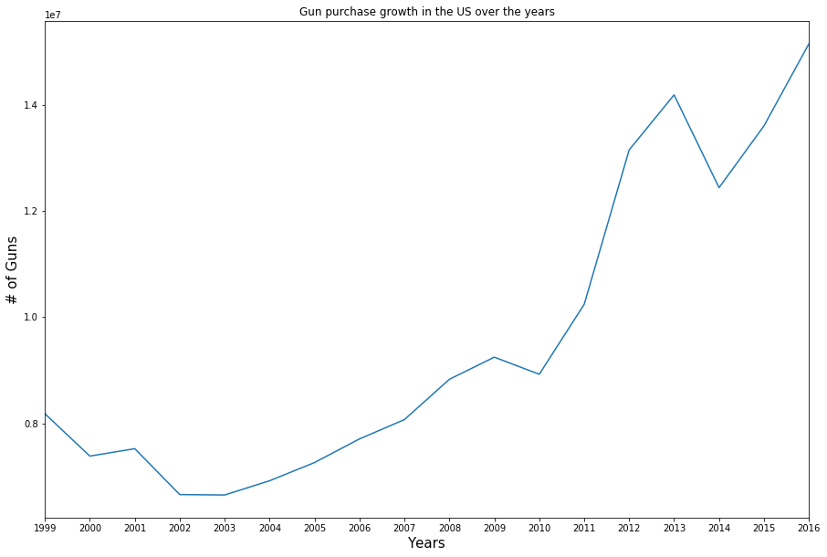

```python
# using line plot to see the change of gun purchase over years
df_gun_year.plot(title= 'Gun purchase growth in the US over the years')
plt.xticks(range(1999, 2017, 1))
plt.xlabel('Years', fontsize=15)
plt.ylabel('# of Guns', fontsize=15);
plt.rc('figure', figsize=(15, 10))
```

**Results:** The lowest year was 2003 with 6648503 gun purchased. There is another slow time in 2010, but it's still higher than the starting pount on 1999 by 744206 purchase. The numbers are picking up again with a noticeable peak on 2013 (14192375 purchase) followed by a sharp decrease on 2014. with the highest numbers on 2016 with 15156261 purchase.

Even though the data shows some low purchase years after 2008, but overall, there is a consistent increase in the amount of guns purchased over the years in the US.

### 2. How is the average monthly distribution of Gun purchase in the US?

What month shows the highest purchase on average? What month is the lowest?

```python
# getting the mean of every month purchase
df_gun_month = df_gun.groupby('month')['total'].mean()
```

```python
df_gun_month
```

```
month
01    15192.016654
02    16866.268877
03    16903.682210
04    14046.235543
05    12179.352210
06    11908.532918
07    12083.734029
08    14380.541807
09    15340.259585
10    17404.337363
11    19971.615140
12    24996.451807
Name: total, dtype: float64
```

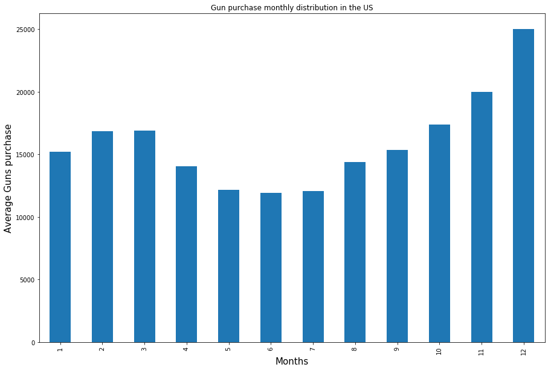

```python
df_gun_month.plot(kind = 'bar', title= 'Gun purchase monthly distribution in the US')
plt.xticks(range(0, 12, 1))
plt.xlabel('Months', fontsize=15)
plt.ylabel('Average Guns purchase', fontsize=15);
plt.rc('figure', figsize=(15, 10))
```

```python
df_gun.groupby('month')['total'].std()
```

```
month
01    16584.369311
02    17401.769355
03    16893.084764
04    14144.948331
05    12816.128956
06    12879.227441
07    13140.167988
08    14507.525474
09    14314.644249
10    15682.496554
11    19494.146895
12    26269.677464
Name: total, dtype: float64
```

**Results:** The numbers reflect December as the busiest month of the year for gun purchase. Numbers drop on January to pick up slightly during February and March,the lowest and stable period on midyear, between may and July. The increase starts to pick up again on August.

### 3. How purchase of different types of guns changed in the US over years?

```python
# Calculating the final total number of every type and all types together
handgun = df_gun['handgun'].sum()
long_gun = df_gun['long_gun'].sum()
other = df_gun['other'].sum()
multiple = df_gun['new_multiple'].sum()
everything = handgun + long_gun + other
```

##### I will be distributing the value of multiple to other typs.

To do that:

- I'll be taking the proportion of every type from the total and using that proportion to get the number of every type in "new_mutltiple"
- After getting the amount of every type in "new_multiple", I will be adding the amount of that type to it, then calculate the proportion of that type from the total

```python
df_gun['handgun_prop'] = (((((df_gun['handgun']/everything)*100)*df_gun['new_multiple']/100)+df_gun['handgun'])/df_gun['total'])*100
df_gun['long_gun_prop'] = (((((df_gun['long_gun']/everything)*100)*df_gun['new_multiple']/100)+df_gun['long_gun'])/df_gun['total'])*100
df_gun['other_prop'] = (((((df_gun['other']/everything)*100)*df_gun['new_multiple']/100)+df_gun['other'])/df_gun['total'])*100
```

```python
#taking the mean of all gun types purchase proportions and filtering by year
df_prop = df_gun.groupby('year')[['handgun_prop', 'long_gun_prop', 'other_prop']].mean()
```

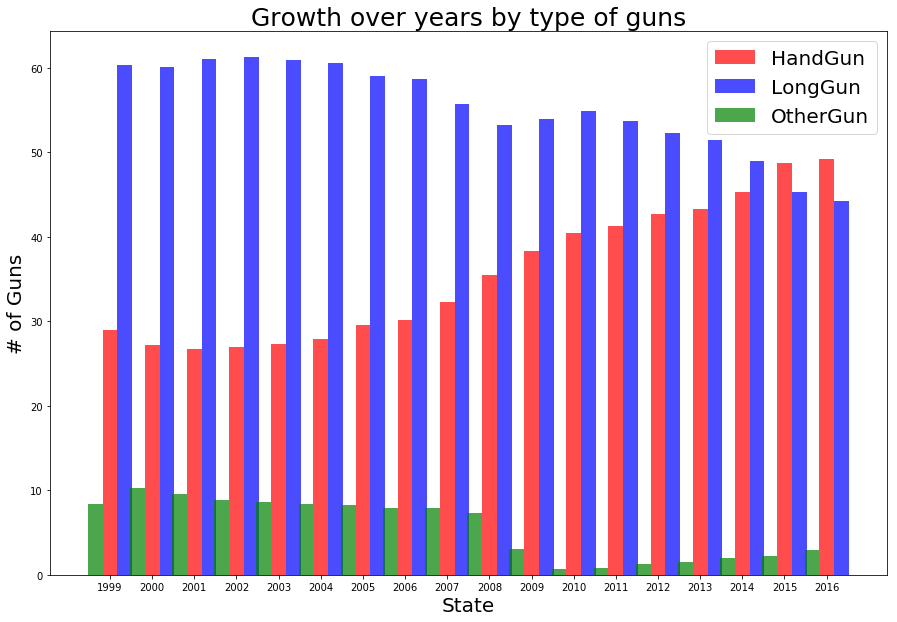

```python
ind = np.arange(len(df_prop))  # the x locations for the groups
width = 0.35

# plotting my bars
handgun_bars = plt.bar(ind, df_prop['handgun_prop'], width, color='r', alpha=.7, label='HandGun')
long_gun_bars = plt.bar(ind + width, df_prop['long_gun_prop'], width, color='b', alpha=.7, label='LongGun')
other_bars = plt.bar(ind - width, df_prop['other_prop'], width, color='g', alpha=.7, label='OtherGun')

# title and labels
plt.ylabel('# of Guns', fontsize=20)
plt.xlabel('State', fontsize = 20)
plt.title('Growth over years by type of guns', fontsize=25)
locations = ind  # xtick locations
labels = df_prop.index  # xtick labels
plt.xticks(locations, labels)
plt.rc('figure', figsize=(40, 20))

plt.legend(fontsize=20) # legend
```

**Results:** According to the data and graph, long_guns started really high in early years, they show a slight almost consistent decrease over the years. While handguns started low, almost have the proportion of long gun, they show a consistent and gradual increase to beat other types in recent years.

Other types show very low amounts from early years, around 3rd the proportion of handguns, they kept an almost stable numbers until 2009, where they dropped to almost the half, and even more on 2010. although they show some increase in recent years, but it's still didn't beat the 2009 numbers.

From the total guns purchases, the proportion of handguns in the last couple of years is the highest, and although long gun are still quite popular, they show a consistent decrease that might continue to coming years.

### 4. How purchase of different types of guns is distributed among US States?

Which state has the highest purchase in every gun type? Which state has the lowest? which is the dominant type in by state purchase?

```python
# calculating the total purchase for every state

df_state_mean = df_gun.groupby('state')[['handgun_prop', 'long_gun_prop', 'other_prop']].mean()
```

```python
df_state_mean.sort_values('handgun_prop')
```

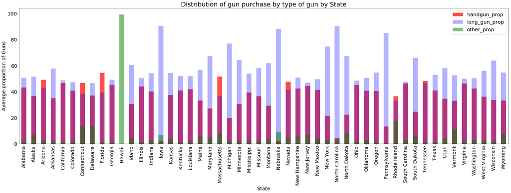

```python
# plotting the three columns

df_state_mean['handgun_prop'].plot(kind='bar', color='red', alpha = .7);
df_state_mean['long_gun_prop'].plot(kind='bar', color='blue', alpha = .3);
df_state_mean['other_prop'].plot(kind='bar', color='green', alpha = .5);

plt.title('Distribution of gun purchase by type of gun by State', fontsize = 25)
plt.xticks(fontsize = 20)
plt.yticks(fontsize = 20)
plt.xlabel('State', fontsize = 20)
plt.ylabel('Average proportion of Guns', fontsize = 20)
plt.rc('figure', figsize=(35, 10))

plt.legend(fontsize=20); # legend
```

**Results:** Iowa has the highest average proportion when it comes to long_gun buying 90.5. Right after comes North Carolina then Nebraska and Pennsylvania between 90 and 85 average percentage of total gun purchases.

Florida with 54.5 then Massachusetts with 52 average percentage are the highest in handgun buying. While Hawaii shows the highest in buying other types of guns 99 average of total purchases.

Is the change in gun purchase percent compatible with different types of human race percent in 2016 or not? Is there a strong positive or negative correlation?

```python
#creating a new dataframe that has the data of only 2016
df_gun_16 = df_gun.query('year == "2016"')
df_gun_sum = df_gun_16.groupby('state').sum()
df_gun_sum = df_gun_sum.copy()
```

```python
# confirming my change
df_gun_sum
```

```python
# getting the total final number of all sales for all states and all included years
total_gun = df_gun_sum['total'].sum()

# then getting the proportion of every every state buying amount from the total amount
df_gun_sum['gun_prop'] = df_gun_sum['total']/total_gun*100
```

```python
# creating a list of the gun_prop column and appending it to the second column
mylist = df_gun_sum["gun_prop"].tolist()

df_census['gun_prop']= mylist
```

```python
#I realized some NaN values for Hawaii, mostly because Hawaii has 0 for all types of sales on 2016.
#So I'll replace the NaN values with 0
df_census.fillna(0, inplace = True)
```

```python
# confirming my change
df_census.head(2)
```

|  | state | Black | Native Indian, Alaska | Asian | Hawaiian, Pacific Islander | Hispanic or Latino | White | Population, percent change, 2010-2016 | Persons in poverty, percent | gun_prop |
| --- | --- | --- | --- | --- | --- | --- | --- | --- | --- | --- |
| 0 | Alabama | 26.8 | 0.7 | 1.4 | 0.1 | 4.2 | 65.8 | 1.7 | 17.1 | 1.941640 |
| 1 | Alaska | 3.8 | 15.2 | 6.3 | 1.3 | 7.0 | 61.2 | 4.5 | 9.9 | 0.540364 |

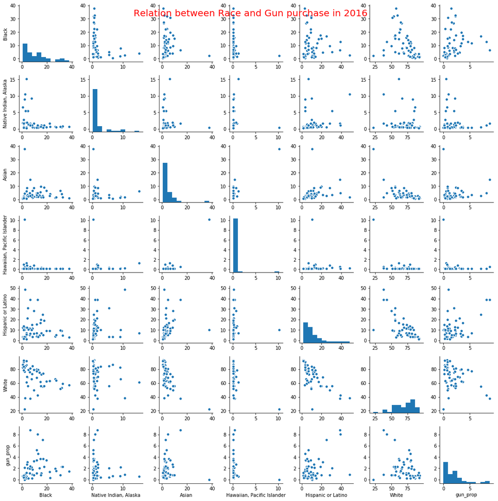

```python
g = sns.pairplot(df_census[['Black','Native Indian, Alaska','Asian','Hawaiian, Pacific Islander', 'Hispanic or Latino', 'White', 'gun_prop']]);

g.fig.suptitle('Relation between Race and Gun purchase in 2016', fontsize=20,color="r",alpha=1);
g.fig.set_size_inches(15,15);
```

**Results:** The data shows a positive correlation between the percentage of gun purchases in 2016 and the percentage of African American, Asian, and Hispanic or Latino in the US. But it shows a negative correlation for the percentage of white and Native Indian, Alaska with the percentage of gun purchased. It's interesting to see there are no correlation with the percentage of Hawaiian, Pacific Islander race.

There is no strong correlation to suggest that a change in one variable is solely affected by the change in the other one.

### 6. How close is the change in population to the change in Gun purchase between 2010 and 2016 in the US?

Is population growing faster than gun purchase growth or the opposite? How much is the difference?

```python
# creating a new dataframe filtered by state and year with the sum value for all other columns.
df_gun_change = df_gun.groupby(['state', 'year']).sum()
```

```python
#creating two dataframes by year, from the filtered one
df_gun_16 = df_gun_change.query('year == "2016"')
df_gun_10 = df_gun_change.query('year == "2010"')
```

```python
#Creating lists from the total of each year
mylist_16 = df_gun_16["total"].tolist()
mylist_10 = df_gun_10["total"].tolist()
```

```python
# adding the new values as columns in the second dataframe.
df_census['total_buy_16']= mylist_16
df_census['total_buy_10']= mylist_10
```

```python
# i would like to compare the change between two years, so i'll be calculating that
df_census['per_change'] = (df_census['total_buy_16'] - df_census['total_buy_10']) / df_census['total_buy_10']*100
```

```python
#I realized some NaN values for Hawaii, mostly because Hawaii has 0 for all types of sales between 2010 and 2016.
#So I'll replace the NaN values with 0
df_census.fillna(0, inplace = True)
```

```python
# taking the mean value for each change will help me see how close they are

gun_change = df_census['per_change'].mean()
pop_change = df_census['Population, percent change, 2010-2016'].mean()
```

```python
# checking my numbers
print (gun_change, pop_change)
```

```
64.5255195462 4.18
```

```python
#calculating the difference
print (gun_change / pop_change)
```

```
15.4367271642
```

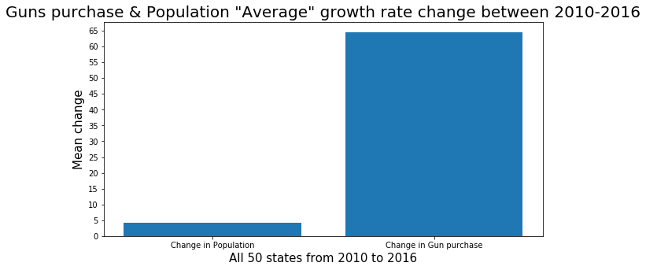

```python
locations = [1, 2] # for the xticks position
heights = [pop_change, gun_change] #for the xtickes data
labels = ['Change in Population', 'Change in Gun purchase'] #for the xticks labels

#Plotting my bars
plt.bar(locations, heights, tick_label=labels);
plt.title('Guns purchase & Population "Average" growth rate change between 2010-2016', fontsize = 20)
plt.xlabel('All 50 states from 2010 to 2016', fontsize = 15)
plt.ylabel('Mean change', fontsize = 15);
plt.yticks(range(0,66, 5));
plt.rc('figure', figsize=(10, 5))
```

**Results:** Based on the average value for change in growth rate between 2010 and 2016. It looks like gun purchase is growing way faster and more than population is growing.

Gun purchase is growing almost 15.5 times faster than population is growing.

### 7. How close is the change in population to the change in Gun purchase between 2010 and 2016 in "every state" in the US?

How do both changes look like for every state? do all states have the gun purchase growth beating the population growth? Does it look like a big change between the two variables?

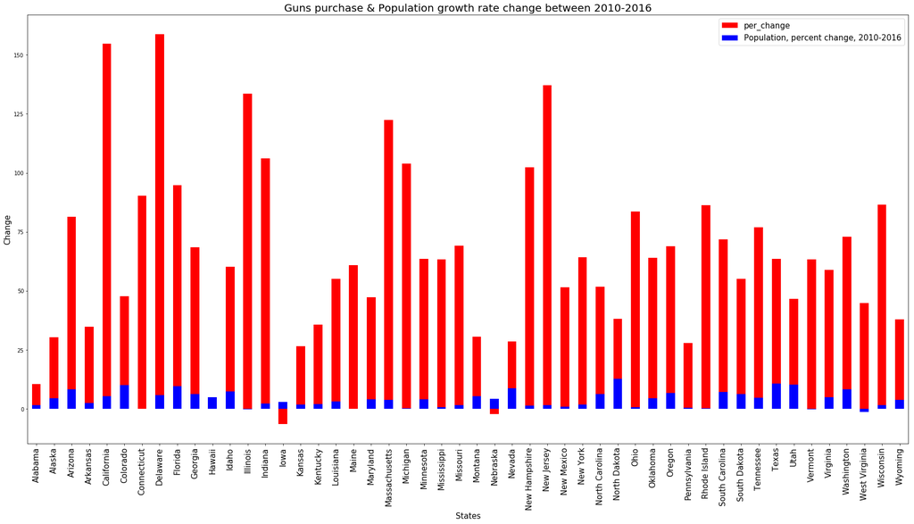

```python
#Plotting my bars
df_census['per_change'].plot(kind='bar', color='red');
df_census['Population, percent change, 2010-2016'].plot(kind='bar', color='blue');

plt.title('Guns purchase & Population growth rate change between 2010-2016', fontsize=20)
plt.xlabel('States', fontsize=15)
plt.ylabel('Change', fontsize=15)
labels = df_census['state']  # xtick labels
plt.xticks(range(0,50, 1), labels, fontsize = 15);
plt.rc('figure', figsize=(30, 15))



plt.legend(fontsize=15); # legend
```

**Results:** The change in gun purchase is so high for some states like Delaware, California, Massachusetts. Some states like Iowa and Nebraska have a negative change in the Gun buying.

States like Hawaii has no Gun buying records between 2010 and 2016

The graph shows a big difference between the two variables, where gun purchase change percent is beating the populaion change precent except for few states like Iowa, Nebraska and Hawaii with a small or no change in the gun purchase percent.

##### The above got me thinking....

### 8. What is the ratio of the change in gun buying to the change in population?

How big is the change between the two percents? are all states have a big difference between the percentage of gun purchase growth change and the population change percentage?

```python
# calculating ratio between my two variables

df_ratio = df_census['per_change'] / df_census['Population, percent change, 2010-2016']
```

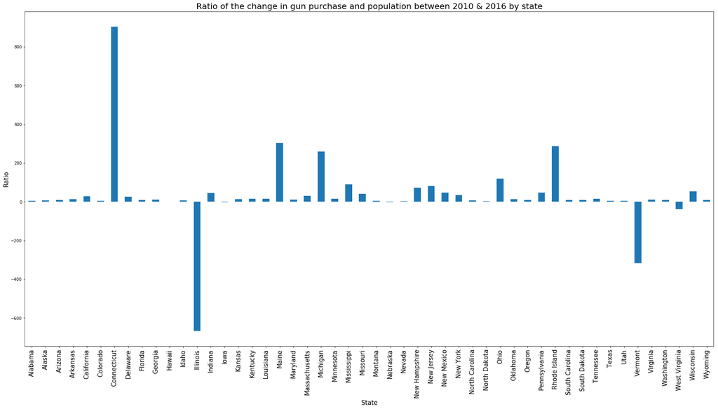

```python
#Plotting

df_ratio.plot(kind = 'bar')
labels = df_census['state']  # xtick labels
plt.xticks(range(0,50, 1), labels, fontsize = 15);

plt.ylabel('Ratio', fontsize=15)
plt.xlabel('State', fontsize = 15)
plt.title("Ratio of the change in gun purchase and population between 2010 & 2016 by state", fontsize=20)
plt.rc('figure', figsize=(40, 20));
```

For Hawaii, the gun purchase recorded was 0, so no ratio is returned.

A fwa states are showing a large positive raio because of the low population change and high gun purchase increase according to the datasets, Connecticut is the highest among them

Overall, based on the ratio, gun purchase is growing faster than population is.

##### I'm still curious to see:

### 9. How is the difference in purchase in every state between 2016 and 2010?

What statse is showing the highest growth between the tewo years? Which one is showing the lowest?

```python
purchase_diff = df_gun_16.groupby('state')['total'].sum() - df_gun_10.groupby('state')['total'].sum()
```

```python
purchase_diff
```

```
state
Alabama            28097
Alaska             19139
Arizona           136854
Arkansas           45099
California        805995
Colorado          151019
Connecticut        80072
Delaware           31079
Florida           521135
Georgia           140042
Hawaii                 0
Idaho              41272
Illinois          316681
Indiana           253124
Iowa               -2641
Kansas             35443
Kentucky           70339
Louisiana         120722
Maine              39190
Maryland           40658
Massachusetts      71516
Michigan          155863
Minnesota         115785
Mississippi        87937
Missouri          212685
Montana            23895
Nebraska            -591
Nevada             25634
New Hampshire      58468
New Jersey         70452
New Mexico         46807
New York          136232
North Carolina     71381
North Dakota       15818
Ohio              316560
Oklahoma          129213
Oregon            131386
Pennsylvania      174788
Rhode Island       13596
South Carolina     98543
South Dakota       33211
Tennessee         242013
Texas             476187
Utah               34225
Vermont            15596
Virginia          192123
Washington        170734
West Virginia      58044
Wisconsin         165651
Wyoming            14415
Name: total, dtype: int64
```

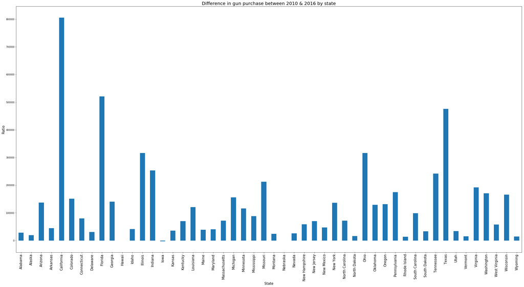

```python
purchase_diff.plot(kind = 'bar')
labels = df_census['state']  # xtick labels
plt.xticks(range(0,50, 1), labels, fontsize = 15);
plt.ylabel('Ratio', fontsize=15)
plt.xlabel('State', fontsize = 15)
plt.title("Difference in gun purchase between 2010 & 2016 by state", fontsize=20)
plt.rc('figure', figsize=(40, 20));
```

**Results:** Hawaii is showing 0 purchase in both years. nebraska and Iowa has a negative chnage due to less gun purchase in 2016 compared to 2010 California shows the highest increase with 805995 more gun purchase in 2016 than 2010. Florida comes next then Texas. 521135 and 476187 respectively.

## Conclusions

**Limitations:**

- Assuming that all gun stors have a good quality and were commited to add entries for all purchases, this is the only data we had, the private sale is incomplete, also it doesn't include under-the-table purchases.
- The census data only includes registered population, there are many people in the US that are not registered
- The data in both datasets is not complete, some years are missing, there are so many null values even if the years with the 12 months.
- The census data doesn't include all states.
- There was some inconsistencies in the data format, i had to assume a certain format based on intuition.
- The data had some outliers that i decided to include in my analysis
- There are not enough facts to make a strong correlation to show that the change in one variable is solely affected by the change in the other one.

##### With the limitation in the data i had, and based on my analysis, these are my "TENTATIVE" findings:

Overall, the data shows an increase in number of guns purchased in the US. On average, the highest number of purchese was done on December, while May, June and july have the least number.

The data shows that in previous years, the number of long gun purchases was higher than any other type, then it started to slightly decrease. While handgun purchase shows a gradual increase to beat long guns purchase in 2015 and 2016.

Looking at different gun types purchase in the states, Florida and Massachusetts are the highest in handgun buying. While Hawaii shows the highest in buying other types of guns. As for long gun, Iowa has the highest number then comes North Carolina, Nebraska and Pennsylvania.

The data suggests that the change in the growth rate for gun purchase over the US between the years 2010 and 2016 is way higher than that of the population for the same years.

According to the data, some states like Delaware, California, Massachusetts shows a very high change in gun purchase. While others, like Iowa and Nebraska, have a negative change, it might be that people are buying less Guns in 2016 than they used to in 2010, but we can state it as a fact without more data to confirm it.

Some states, has a negative ratio due to a recorded negative population change. While others have a high ratio, due to the recorded low population growth rate change and high gun purchase increase.

```python
from subprocess import call
call(['python', '-m', 'nbconvert', 'Investigate_a_Dataset.ipynb'])
```